# Final Report

Ana Fernandes PG38284, João Capela PG38274, Tiago Ferreira PG33765, Tiago Oliveira PG24096

2020-06-04

# 1 Introduction

Gastric Cancer (GC) is recognized as one of the causes of cancer incidence around the globe. Moreover, it was identified as the third major cause of death by oncological disease. To the best of our knowledge, there are several factors associated to the formation and progression of GC, namely molecular, genetic, environmental factors, and epigenetic alterations. As for epigenetic alterations, DNA methylations, histone modifications, nucleossome positioning and non codifying RNA. Following up the work of Baek and collaborators (2015), this analysis will focus on DNA methylation. This phenomenon has been reported as one of the major causes of carcinogenesis. Taking into account the work of Baek and collaborators (2015), the main goal of present work is to analyze the RNA-seq data obtained from GC patients and healthy samples. Moreover, it aims at finding differences between proximal and distal regulatory regions of GC patient samples and healthy cases. For this, RNA-seq data of normal and tumoral tissues was analyzed and characterized. This data was divided into the following groups: purified gastric cancer cell (sc), cultured gastric cancer cell (dc) e mixture of several gastric cancer cell clones (mc)) of three patients (csc1, csc2, csc3) and two replicates (csc1_sc2, csc1_sc3) (Table 1)[1].

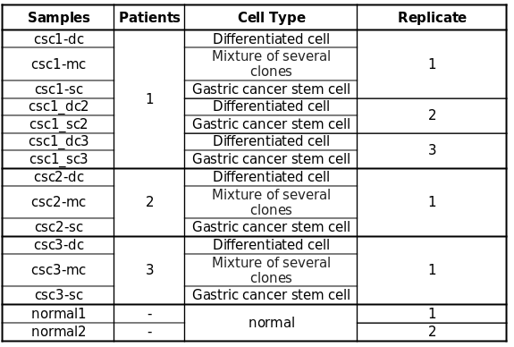

Table 1 - data organization.

# 2 Methods

The study data is constituted by 15 libraries of RNA-Seq paired-end, which were prepared by PCR using the TruSeq RNA Sample Prep Kit (Illumina, San Diego, CA, USA) and sequenced using Hiseq-2000 (Illumina). Each library is in “.fastq.gz” format.

## 2.1 Data quality control

FastQC (version: 0.11.8) was used in order to generate a quality control report of each library. Then, these reports were exported for the folder “fastQC_reports/”, using the following command:

```bash
fastqc -o fastQC_reports/ SRR*
```

## 2.2 Reads management

The library reads were filtered by quality and the adaptors sequences were cut with Trimmomatic (version: 0.39), using the following command:

```bash
for i in {5..8}
do
    trimmomatic PE SRR104158$i\_1.fastq.gz SRR104158$i\_2.fastq.gz Trim/SRR104158$i\_1P Trim/SRR104158$i\_1U Trim/SRR104158$i\_2P Trim/SRR104158$i\_2U ILLUMINACLIP:TruSeq3-PE-2.fa:2:30:10:2:keepBothReads LEADING:0 TRAILING:0 SLIDINGWINDOW:0:0
done

for i in {22..32}
do
    trimmomatic PE SRR8469$i\_1.fastq.gz SRR8469$i\_2.fastq.gz Trim/SRR8469$i\_1P Trim/SRR8469$i\_1U Trim/SRR8469$i\_2P Trim/SRR8469$i\_2U ILLUMINACLIP:TruSeq3-PE-2.fa:2:30:10:2:keepBothReads LEADING:0 TRAILING:0 SLIDINGWINDOW:0:0
done
```

No reads quality parameter was inserted, so that Trimmomatic could determine which limits of the reads quality should be inserted, adequately, to each library.

In order to remove the adaptors sequences, the sequences used in the PCRs were indicated. Moreover, the mismatch and score parameters were set. It was also indicated that the Trimmomatic should consider any adaptor with a given minimum size (2). Lastly, the reverse reads were considered as well.

As for the FastQC report results, no filter was considered per level of quality.

After the Trimmoatic operations, the results were thoroughly analysed, so that the quality could be checked and possible errors identified. For that, that following command was run.

```bash
fastqc -o fastQC_reports/ Trim/SRR*"P"
```

## 2.3 Alignment

The third chromossome of the GRCh38 assembly of the human genome was used as a reference. This reference was indexed and used for the Burrows-Wheeler Aligner (BWA) (version:0.7.17-r1188) library alignment.

The following commands were used for Indexation, aligment and creation of the final “.bam” files.

```bash
bwa index Index/Homo_sapiens.GRCh38.dna.chromosome.3.fa.gz  # Indexacao

ls *.fastq.gz | cut -d "_" -f1 | uniq > fastq_names.txt # Lista de amostras


for fq in $(cat fastq_names.txt)
do
    bwa aln Index/Homo_sapiens.GRCh38.dna.chromosome.3.fa.gz Trim/$fq"_1P" > aln_ch3/$fq"_1.sai"
    bwa aln Index/Homo_sapiens.GRCh38.dna.chromosome.3.fa.gz Trim/$fq"_2P" > aln_ch3/$fq"_2.sai"
done


for fq in $(cat fastq_names.txt)
do
    bwa sampe Index/Homo_sapiens.GRCh38.dna.chromosome.3.fa.gz aln_ch3/$fq"_1.sai" aln_ch3/$fq"_2.sai" Trim/$fq"_1P" Trim/$fq"_2P" | samtools view -S -b > bams_chr3/$fq".bam"
done
```